# Sieci rekurenyjne, część I

## Wprowadzenie

W ramach tej listy badane było działanie sieci rekurencyjnych. W pierwszej części zaimplementowane zostały standardowa sieć RNN oraz sieć LSTM.

## Dane

Zaimplementowane sieci badane były w zadaniu klasyfikowania artykułów opublikowanych w serwisie Reuters. Poniżej przedstawiono oryginalny rozkład klas w zbiorze:

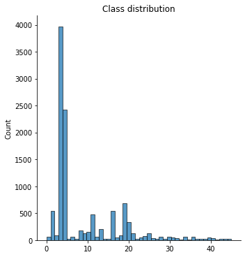

```python
# full code in ipynb file
```

Z powodu wysokiego niezbalansowania klas, do badań wybrane zostało 10 najczęściej występujących klas przedstawionych poniżej:

Due to data inbalance we take only top 10 most frequent classes.

```python
# full code in ipynb file
```

```
{0: 'earn',
 1: 'acq',
 2: 'money-fx',
 3: 'crude',
 4: 'grain',
 5: 'trade',
 6: 'interest',
 7: 'ship',
 8: 'money-supply',
 9: 'sugar'}
```

## Implementacja

Poniżej przedstawiono implementacje najważniejszych komponentów, czyli warstwy embedding oraz warstw rekurencyjnych RNN i LSTM (z wykorzystaniem tf.scan).

### Embedding

```python
class Embedding(tf.keras.layers.Layer):

  def __init__(self, num_words, emb_size):

    super(Embedding, self).__init__()
    self.num_words = num_words
    self.emb_size = emb_size

    self.emb_matrix = self.add_weight(
        shape=([self.num_words, self.emb_size]),
        initializer='random_normal',
        trainable=True
    )

  def __call__(self, words_ids):

    return tf.nn.embedding_lookup(self.emb_matrix, words_ids)
```

### RNN

```python
class RNN(tf.keras.layers.Layer):

  def __init__(self, state_size, input_size, output_size):

    super(RNN, self).__init__()
    self.state_size = state_size
    self.input_size = input_size
    self.output_size = output_size

    self.W_pred = self.add_weight(
        shape=([self.state_size, self.output_size]),
        initializer='random_uniform',
        trainable=True
    )
    self.b_pred = self.add_weight(
        shape=([self.output_size]),
        initializer='random_uniform',
        trainable=True
    )

    self.W_h = self.add_weight(
        shape=([self.state_size, self.state_size]),
        initializer='random_uniform',
        trainable=True
    )
    self.W_x = self.add_weight(
        shape=([self.input_size, self.state_size]),
        initializer='random_uniform',
        trainable=True
    )
    self.b = self.add_weight(
        shape=([self.state_size]),
        initializer='random_uniform',
        trainable=True
    )

  def call(self, x):

    x = tf.transpose(x, perm=[1, 0, 2])

    initial_state = tf.zeros(
      [x.shape[1], self.state_size],
      name='initial_state'
    )
    states = tf.scan(
      self._rnn_step, x,
      initializer=initial_state,
      name='states'
    )

    predictions = tf.add(
        tf.matmul(states, self.W_pred),
        self.b_pred,
        name='predictions'
    )

    return states, predictions

  def _rnn_step(self, h_prev, x):

    h = tf.tanh(
      tf.matmul(h_prev, self.W_h) + tf.matmul(x, self.W_x) + self.b
    )

    return h
```

### LSTM

```python
class LSTM(tf.keras.layers.Layer):

  def __init__(self, state_size, input_size, output_size):

    super(LSTM, self).__init__()
    self.state_size = state_size
    self.input_size = input_size
    self.output_size = output_size

    self.W_f = self.add_weight(
        shape=([self.state_size + self.input_size, self.state_size]),
        initializer='random_uniform',
        trainable=True
    )
    self.b_f = self.add_weight(
        shape=([1, self.state_size]),
        initializer='random_uniform',
        trainable=True
    )

    self.W_i = self.add_weight(
        shape=([self.state_size + self.input_size, self.state_size]),
        initializer='random_uniform',
        trainable=True
    )
    self.b_i = self.add_weight(
        shape=([1, self.state_size]),
        initializer='random_uniform',
        trainable=True
    )

    self.W_C = self.add_weight(
        shape=([self.state_size + self.input_size, self.state_size]),
        initializer='random_uniform',
        trainable=True
    )
    self.b_C = self.add_weight(
        shape=([1, self.state_size]),
        initializer='random_uniform',
        trainable=True
    )

    self.W_o = self.add_weight(
        shape=([self.state_size + self.input_size, self.state_size]),
        initializer='random_uniform',
        trainable=True
    )
    self.b_o = self.add_weight(
        shape=([1, self.state_size]),
        initializer='random_uniform',
        trainable=True
    )

    self.W_v = self.add_weight(
        shape=([self.state_size, self.output_size]),
        initializer='random_uniform',
        trainable=True
    )
    self.b_v = self.add_weight(
        shape=([1, self.output_size]),
        initializer='random_uniform',
        trainable=True
    )

  def call(self, x):

    x = tf.transpose(x, perm=[1, 0, 2])

    initial_h_state = tf.zeros(
      [x.shape[1], self.state_size]
    )
    initial_C_state = tf.zeros(
      [x.shape[1], self.state_size]
    )
    initial_state = (initial_h_state, initial_C_state)

    states = tf.scan(
      self._lstm_step, x,
      initializer=initial_state,
      name='states'
    )

    h_states = states[1]

    predictions = tf.add(
        tf.matmul(h_states, self.W_v),
        self.b_v,
        name='predictions'
    )

    return states, predictions

  def _lstm_step(self, prev_result, x):

    (C_state_prev, h_state_prev) = prev_result

    # forget gate

    f_t = tf.sigmoid(
        tf.add(
            tf.matmul(tf.concat((h_state_prev, x), axis = 1), self.W_f),
            self.b_f
        )
    )

    # input gate

    i_t = tf.sigmoid(
        tf.add(
            tf.matmul(tf.concat((h_state_prev, x), axis = 1), self.W_i),
            self.b_i
        )
    )

    cC_state = tf.tanh(
        tf.add(
            tf.matmul(tf.concat((h_state_prev, x), axis = 1), self.W_C),
            self.b_C
        )
    )

    # update C state

    C_state = tf.add(
        f_t * C_state_prev,
        i_t * cC_state
    )

    # update h state

    o_t = tf.sigmoid(
        tf.add(
            tf.matmul(tf.concat((h_state_prev, x), axis = 1), self.W_o),
            self.b_o
        )
    )

    h_state = o_t * tf.tanh(C_state)

    return (C_state, h_state)
```

## Badania

Sprawdzono jakość klasyfikacji dla sieci RNN i LSTM w zależności od ograniczania zbioru do 250, 500, 1000 lub 2000 najczęściej wystepujących słów. Wartości pozostałych himerparametrów, to:

- liczba słów w artykule: 100 (artykuł ucinano do 100 słów lub gdy był krótszy dopełniano zerami, aby na wejściu modeli otrzymywać wektory 100 elementowe),
- rozmiar embeddingu: 32,
- rozmiar stanu ukrytego warstwy rekurencyjnej: 64,
- optymalizator: Adam,
- współczynnik uczenia: 0.001,
- liczba epok: 100,
- wielkość paczki: 500.

## Wyniki

Tabela przedstawia wyniki wszystkich testowanych modeli. Dodatkowo w załączniku Zal_1.html zapisane zostały przebiegi uczenia wszystkich modeli.

```python
# full code in ipynb file
```

|  | index | model | num_words | input_size | embedding_size | state_size | optimizer | lr | epochs | batch | best_val_loss | best_val_acc | best_val_f1 |
| --- | --- | --- | --- | --- | --- | --- | --- | --- | --- | --- | --- | --- | --- |
| 6 | 6 | Model2_LSTM | 1000 | 100 | 32 | 64 | adam | 0.001 | 100 | 500 | 2.285933 | 0.697687 | 0.274395 |
| 2 | 2 | Model1_RNN | 1000 | 100 | 32 | 64 | adam | 0.001 | 100 | 500 | 2.217672 | 0.651420 | 0.255895 |
| 4 | 4 | Model2_LSTM | 250 | 100 | 32 | 64 | adam | 0.001 | 100 | 500 | 2.286945 | 0.690852 | 0.250072 |
| 3 | 3 | Model1_RNN | 2000 | 100 | 32 | 64 | adam | 0.001 | 100 | 500 | 2.259909 | 0.667192 | 0.242333 |
| 7 | 7 | Model2_LSTM | 2000 | 100 | 32 | 64 | adam | 0.001 | 100 | 500 | 2.267496 | 0.682440 | 0.236533 |
| 1 | 1 | Model1_RNN | 500 | 100 | 32 | 64 | adam | 0.001 | 100 | 500 | 2.203737 | 0.657203 | 0.232633 |
| 5 | 5 | Model2_LSTM | 500 | 100 | 32 | 64 | adam | 0.001 | 100 | 500 | 2.246664 | 0.679811 | 0.213631 |
| 0 | 0 | Model1_RNN | 250 | 100 | 32 | 64 | adam | 0.001 | 100 | 500 | 2.219576 | 0.645110 | 0.208049 |

### Najlepszy model RNN

Przebieg uczenia najlepszego modelu RNN:

```
--------MODEL--------

Model1_RNN

Num words:  1000

Best validation Loss:  2.217672348022461
Best validation Accuracy:  0.6514195799827576
Best validation F1Score:  0.2558949589729309
```

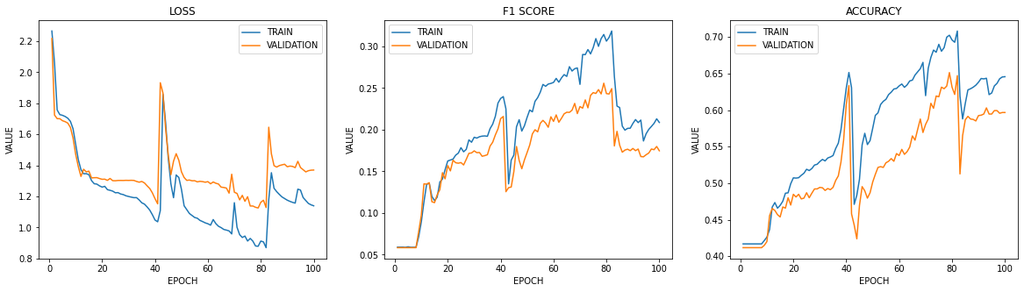

```python
# full code in ipynb file
```

Wartość miary F1 na zbiorze testowym:

```python
# full code in ipynb file
```

```
Test F1: 0.1621969799582313
```

Miary klasyfikacji dla każdej klasy:

```python
# full code in ipynb file
```

```
              precision    recall  f1-score   support

        earn       0.84      0.92      0.88       811
         acq       0.42      0.72      0.53       460
    money-fx       0.10      0.12      0.11       139
       crude       0.00      0.00      0.00       119
       grain       0.00      0.00      0.00        98
       trade       0.12      0.05      0.08        92
    interest       0.08      0.01      0.02        72
        ship       0.00      0.00      0.00        43
money-supply       0.00      0.00      0.00        40
       sugar       0.00      0.00      0.00        28

    accuracy                           0.58      1902
   macro avg       0.16      0.18      0.16      1902
weighted avg       0.48      0.58      0.52      1902
```

Macierz pomyłek:

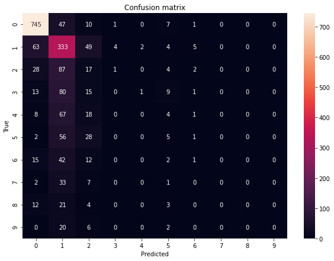

```python
# full code in ipynb file
```

### Najlepszy model LSTM

Przebieg uczenia dla najlepszego modelu LSTM:

```
--------MODEL--------

Model2_LSTM

Num words:  1000

Best validation Loss:  2.2859325408935547
Best validation Accuracy:  0.6976866722106934
Best validation F1Score:  0.2743948698043823
```

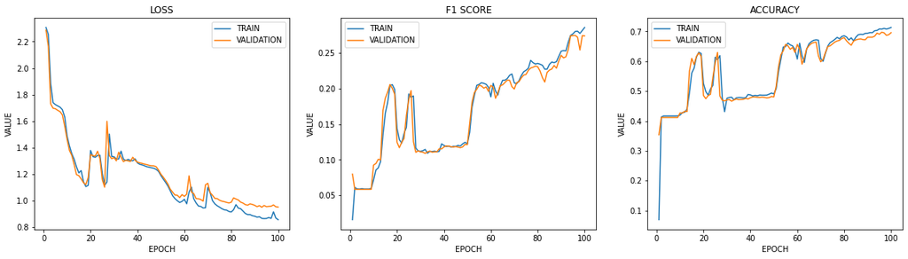

```python
# full code in ipynb file
```

```python
# full code in ipynb file
```

```
Test F1: 0.2784583838971523
```

Miary klasyfikacji dla każdej klasy:

```python
# full code in ipynb file
```

```
              precision    recall  f1-score   support

        earn       0.92      0.93      0.92       811
         acq       0.80      0.85      0.82       460
    money-fx       0.32      0.68      0.43       139
       crude       0.50      0.08      0.13       119
       grain       0.16      0.29      0.21        98
       trade       0.26      0.27      0.27        92
    interest       0.00      0.00      0.00        72
        ship       0.00      0.00      0.00        43
money-supply       0.00      0.00      0.00        40
       sugar       0.00      0.00      0.00        28

    accuracy                           0.69      1902
   macro avg       0.30      0.31      0.28      1902
weighted avg       0.66      0.69      0.66      1902
```

Macierz pomyłek:

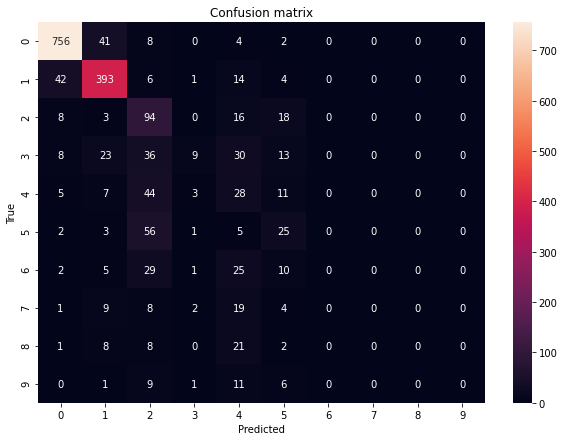

```python
y_pred = tf.math.argmax(y_pred_probs, 1)
# full code in ipynb file
```

## Wnioski

- Obydwie metody osiągnęły zbliżone najlepsze wartości metryki F1.
- Sieć LSTM potencjalnie mogła dać lepsze wyniki, ponieważ w momencie zakończenia uczenia wartości metryk nadal się porpawiały, natomiast wartości metryk sieci RNN prezentują duzy spadek po 80 epoce.
- Uczenie sieci RNN wygląda bardziej stabilnie. Przed osiągnięciem najlepszego wyniku widoczny jest tylko jeden większy spadek metryk.
- W przypadku sieci LSTM możemy zaobserwować długie wypłaszczenie metryk między 30 i 50 epoką. W przypadku stosowania wcześniejszego zatrzymania uczenie zostałoby wtedy przerwane.
- Obydwie metody potrzebują dużo czasu na uczenie i z pewnością mogłyby dać jeszcze lepsze wyniki.
- Sieci najlepsze wyniki dały w przypadku dwóch najliczniej reprezetnowanych klas.
- Sieć LSTM po zakończeniu uczenia dała obiecujące wyniki również w przyadku mniej licznych klas.